# TitanicDataAnalysis

From the data , I want to find out if the Gender / Pclass / Age has any impact on the survival chances of the passengers.

```python
import pandas as pd
import numpy as np
import scipy.stats as st

%pylab inline

titanic_data=pd.read_csv("titanic_data.csv")

print titanic_data.info()

print titanic_data.describe()
```

```
<class 'pandas.core.frame.DataFrame'>
Int64Index: 891 entries, 0 to 890
Data columns (total 12 columns):
PassengerId    891 non-null int64
Survived       891 non-null int64
Pclass         891 non-null int64
Name           891 non-null object
Sex            891 non-null object
Age            714 non-null float64
SibSp          891 non-null int64
Parch          891 non-null int64
Ticket         891 non-null object
Fare           891 non-null float64
Cabin          204 non-null object
Embarked       889 non-null object
dtypes: float64(2), int64(5), object(5)
memory usage: 90.5+ KB
None
       PassengerId    Survived      Pclass         Age       SibSp  \
count   891.000000  891.000000  891.000000  714.000000  891.000000
mean    446.000000    0.383838    2.308642   29.699118    0.523008
std     257.353842    0.486592    0.836071   14.526497    1.102743
min       1.000000    0.000000    1.000000    0.420000    0.000000
25%     223.500000    0.000000    2.000000   20.125000    0.000000
50%     446.000000    0.000000    3.000000   28.000000    0.000000
75%     668.500000    1.000000    3.000000   38.000000    1.000000
max     891.000000    1.000000    3.000000   80.000000    8.000000

            Parch        Fare
count  891.000000  891.000000
mean     0.381594   32.204208
std      0.806057   49.693429
min      0.000000    0.000000
25%      0.000000    7.910400
50%      0.000000   14.454200
75%      0.000000   31.000000
max      6.000000  512.329200
```

From above info command output , we can see that out of total 891 entries ,Age has only 714 values(177 missing) , Cabin has 204 (687 missing) and embarked has 889 (2 missing) .

Let us fill the missing age values with the median value of age of male / female in each Pclass (Median to reduce impacts of the outliers) and populate a new column AgeRefined.

Let us create helper functions to group by a key column , survivors in a group , classify ages to groups and populate missing Age values with medians

```python
def age_groups(age):
    if age<=15:
        return 0
    elif age>15 and age <=40:
        return 1
    elif age >40 and age<=60:
        return 2
    elif np.isnan(age):
        return None
    else:
        return 3
    return none

def gender_map(sex):
    if sex=='female':
        return 0
    elif sex=='male':
        return 1
    else:
        return 2

def survivors_by_group(group_by_field,survived):
    new_df=titanic_data.groupby(group_by_field)
    return_data={}
    #print "==============================="
    #print "Grouping by:",group_by_field," and filtering on survived:",survived
    for groups in new_df.groups.keys():
        group_data=titanic_data.groupby(group_by_field).get_group(groups)
        survival_group_data=group_data[group_data["Survived"]==survived]
        return_data[groups]=survival_group_data
    #print return_data.keys()
    return return_data

def data_by_group(group_by_field):
    new_df=titanic_data.groupby(group_by_field)
    return_data={}
    #print "==============================="
    #print "Grouping by:",group_by_field," and filtering on survived:",survived
    #print new_df.groups.keys()
    for groups in new_df.groups.keys():
        group_data=titanic_data.groupby(group_by_field).get_group(groups)
        return_data[groups]=group_data
    return return_data

def fillna_with_median(dict1):
    if np.isnan(dict1["Age"]):
        dict1["AgeRefined"]=median_dict[(dict1["Sex"],dict1["Pclass"])]
        #print dict1["Age"],dict1["AgeGroup"]
        return dict1["AgeRefined"]
    else:
        return dict1["Age"]

titanic_data_by_sex_bypclass=data_by_group(["Sex","Pclass"])
#print titanic_data_by_sex_bypclass
median_dict={}
for keys in titanic_data_by_sex_bypclass.keys():
    median_dict[keys]=np.median(titanic_data_by_sex_bypclass[keys]["Age"])

titanic_data["AgeRefined"]=titanic_data.apply(fillna_with_median,axis=1)
#print titanic_data["AgeRefined"]

titanic_data["AgeGroup"]=titanic_data["AgeRefined"].apply(age_groups)
titanic_data["Gender"]=titanic_data["Sex"].apply(gender_map)

print titanic_data.groupby("Survived")[["Age","AgeRefined","AgeGroup","Pclass","Gender"]].mean()
```

```
                Age  AgeRefined  AgeGroup    Pclass    Gender
Survived
0         30.626179   30.978142  1.171220  2.531876  0.852459
1         28.343690   28.838216  1.046784  1.950292  0.318713
```

From the above output ( based on groupby of Survived ) 1. Mean value of Gender , for Survived=1 is tending more towards 0 (female) and Survived=0 is tending more towards 1 (male) . In other words, survival chances of female passengers are more than male passengers. 2. Pclass mean value for Survived=1 is 1.9 <2 and Survived=0 is 2.53 >2 . It indicates that the probability of Survival of passengers in Cabin 1 and 2 is relatively higher than probability of survival of passengers in 2 and 3. 3. AgeGroup mean value does not indicate anything in partcular.

Below are a few bar charts to visualize this data

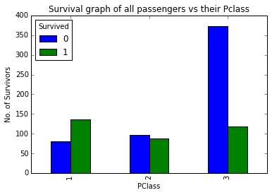

```python
#Survivors by Pclass

pd.crosstab(titanic_data["Pclass"],titanic_data["Survived"] ).plot(kind='bar')
plt.title('Survival graph of all passengers vs their Pclass')
plt.xlabel('PClass')
plt.ylabel('No. of Survivors')
```

The above is a plot to indicate the number of Survivors in each Pclass. We can clearly see that the passengers in Pclass 1 had a high survival ratio where as the Pclass3 had the lowest survival ratio. Let us also see the survival plot of men and women in each Pclass.

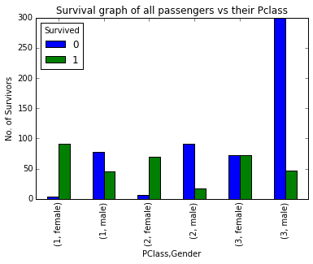

```python
pd.crosstab([titanic_data["Pclass"],titanic_data["Sex"]],titanic_data["Survived"] ).plot(kind='bar')
plt.title('Survival graph of all passengers vs their Pclass')
plt.xlabel('PClass,Gender')
plt.ylabel('No. of Survivors')
```

The above graph shows that female passengers from Pclass 1 and 2 had the highest survival ratio. Male passengers in almost all the Pclass have lesser survival ratio , compared to female passengers in the same Pclass and male passengers in Pclass 3 has the lowest survival ratio of all.

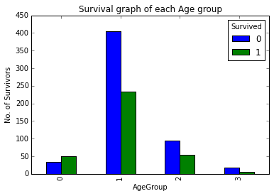

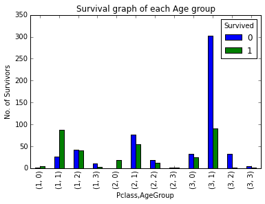

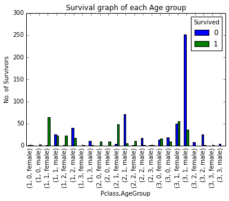

```python
#Survivors by age group
pd.crosstab(titanic_data["AgeGroup"],titanic_data["Survived"] ).plot(kind='bar')
plt.title('Survival graph of each Age group')
plt.xlabel('AgeGroup')
plt.ylabel('No. of Survivors')


#Survivors by age group
pd.crosstab([titanic_data["Pclass"],titanic_data["AgeGroup"]],titanic_data["Survived"] ).plot(kind='bar')
plt.title('Survival graph of each Age group')
plt.xlabel('Pclass,AgeGroup')
plt.ylabel('No. of Survivors')


#Survivors by age group
pd.crosstab([titanic_data["Pclass"],titanic_data["AgeGroup"],titanic_data["Sex"]],titanic_data["Survived"] ).plot(kind='bar')
plt.title('Survival graph of each Age group')
plt.xlabel('Pclass,AgeGroup')
plt.ylabel('No. of Survivors')
```

From above graphs , we can see that most of the casualties belong to age group 1(16 to 40) , but majority of those belong to the Pclass 3 and are male passengers. Though I expected the survival chance of age group 16 - 40 to be more , the fact that most of them belonging to Pclass 3 reduced it.

Let us perform a hypothetical test with Null and Alternate hypotheses as below

Null hypotheses H0: Px-Py <= 0 Alternate Hypotheses HA: Px-Py > 0

Below is a statistical test for difference between two proportions (Reference : Statistics for Engineers and Scientists by William Navidi 3rd edition)

```python
#Probability of a male passenger's survival
from __future__ import division

Total_male_survivors=len(titanic_data[(titanic_data["Sex"]=='male') & (titanic_data["Survived"]==1)])
Total_male_passengers=len(titanic_data[titanic_data["Sex"]=='male'])
Total_female_survivors=len(titanic_data[(titanic_data["Sex"]=='female') & (titanic_data["Survived"]==1)])
Total_female_passengers=len(titanic_data[titanic_data["Sex"]=='female'])

Px= Total_male_survivors/Total_male_passengers
Py= Total_female_survivors/Total_female_passengers

print Px , Py

# Calculate the pooled proportion
Pooled_proportion=(Total_male_survivors+Total_female_survivors)/(Total_male_passengers+Total_female_passengers)
print Pooled_proportion

#The value of standard deviation
#variance=(Pooled_proportion*(1-Pooled_proportion))*(1/Total_male_passengers)+(1/Total_female_passengers)
Std_dev=sqrt((Pooled_proportion*(1-Pooled_proportion))*(1/Total_male_passengers)+(1/Total_female_passengers))
print Std_dev

#Mean value of Null distribution for Px-Py is 0 and for the observed is
z=((Px-Py)-0)/Std_dev
print z

print "P value is ",st.norm.cdf(z)
```

```
0.188908145581 0.742038216561
0.383838383838
0.059955010527
-9.22575221184
P value is  1.40788755326e-20
```

From the P value , we can reject the null hypotheses .

```python
Total_Pclass3_passengers=len(titanic_data[titanic_data["Pclass"]==3])
Total_Pclass_survivors=len(titanic_data[(titanic_data["Pclass"]==3) & titanic_data["Survived"]==1 ])

Total_remaining_passengers=len(titanic_data[titanic_data["Pclass"]!=3])
Total_remaining_survivors=len(titanic_data[(titanic_data["Pclass"]!=3) & titanic_data["Survived"]==1 ])

print Total_Pclass3_passengers,Total_Pclass_survivors,Total_remaining_passengers,Total_remaining_survivors

PCx=(Total_Pclass_survivors)/(Total_Pclass3_passengers)
PCy=(Total_remaining_survivors)/(Total_remaining_passengers)

Pooled_prop=(Total_Pclass_survivors+Total_remaining_survivors)/(Total_Pclass3_passengers+Total_remaining_passengers)
std_dev=sqrt((Pooled_prop*(1-Pooled_prop))*((1/Total_Pclass3_passengers)+(1/Total_remaining_passengers)))
print Pooled_prop,std_dev

Z=((PCx-PCy)-0)/std_dev
print z
print "P value is ", 2*st.norm.cdf(z)
```

```
491 119 400 223
0.383838383838 0.0327559071589
-9.22575221184
P value is  2.81577510651e-20
```

To conclude : The survival chance of a female passenger was higher than a male passenger ,in any Pclass. Also the survival chance of a male passenger in Pclass 3 was lower than the survival chance of male passengers in other Pclass. We can use these as inputs to write an algorithm to predict Survival.